# EIA Data Updates

Andrew Leach

08 February, 2019

The US Energy Information Administration (EIA) provides a wealth of data for energy markets. This update focusses on their regularly-updated oil and gas data sources including:

- Spot Prices and Some Futures Market Info
- Weekly Petroleum Status Report
- Weekly Gas Storage Reort
- Oil and gas production updates
  - Monthly Production Data by Region
  - Drilling Productivity Reports
  - Shale Gas and Light Tight Oil Production Reports
- Short Term Energy Outlook
- Annual Energy Outlook

For each section, I’ve included R code to access the data as well as links to the web interface for the data. The R code relies on stadard Tidyverse packages as well as a couple of custom functions and an API key. You should be able to run this with the code provided once you get your own key [here](https://www.eia.gov/opendata/register.cfm), and you’ll have to store it in a variable called KEY to get the code to work.

If you’re going to run the R code, you’ll need a few basic set-up elements to get everything to work. I’ve included the code here for your reference.

```r
#packages used
library(RColorBrewer)
library(viridis)
library(scales)
library(pdfetch)
library(tidyverse)
library(lubridate)
library(reshape2)
library(knitr)
library(prettydoc)
library(XML)
library(zoo)
library(openxlsx)

#quick function to make time breaks on axes
make_breaks <- function(strt, hour, interval="day", length.out=31) {
  strt <- as.POSIXlt(strt - 60*60*24)  # start back one day
  strt <- ISOdatetime(strt$year+1900L, strt$mon+1L, strt$mday, hour=hour, min=0, sec=0, tz="UTC")
  seq.POSIXt(strt, strt+(1+length.out)*60*60*24, by=interval)
}

#get multiple series listing from the EIA API
data_fetch<-function(key, cat=2227122){
  key <- unlist(strsplit(key, ";"))
  ifelse(cat==999999999,
         url <- paste("http://api.eia.gov/category?api_key=",
                      key, "&out=xml", sep="" ),
         url <- paste("http://api.eia.gov/category?api_key=",
                      key, "&category_id=", cat, "&out=xml", sep="" )
  )
  doc <- xmlParse(file=url, isURL=TRUE)
  Parent_Category <- tryCatch(xmlToDataFrame(,stringsAsFactors = F,nodes =
                                               XML::getNodeSet(doc, "//category/parent_category_id")),
                              warning=function(w) FALSE, error=function(w) FALSE)
  Sub_Categories <- xmlToDataFrame(,stringsAsFactors = F,nodes =
                                     XML::getNodeSet(doc, "//childcategories/row"))
  Series_IDs <- xmlToDataFrame(nodes =
                                 XML::getNodeSet(doc, "///childseries/row"),stringsAsFactors = F)
  Categories <- list(Parent_Category, Sub_Categories, Series_IDs)
  names(Categories) <- c("Parent_Category", "Sub_Categories", "Series_IDs")
  return(Categories)
}

colors_tableau10 <- function()
{
  return(c("#1F77B4", "#FF7F0E", "#2CA02C", "#D62728", "#9467BD", "#8C564B",
           "#E377C2", "#7F7F7F", "#BCBD22", "#17BECF"))
}

colors_tableau10_light <- function()
{
  return(c("#AEC7E8", "#FFBB78", "#98DF8A", "#FF9896", "#C5B0D5", "#C49C94",
           "#F7B6D2", "#C7C7C7", "#DBDB8D", "#9EDAE5"))
}

colors_tableau10_medium <- function()
{
  return(c("#729ECE", "#FF9E4A", "#67BF5C", "#ED665D", "#AD8BC9", "#A8786E",
           "#ED97CA", "#A2A2A2", "#CDCC5D", "#6DCCDA"))
}
```

# Commodity Prices

Both the EIA data interface [here](https://www.eia.gov/petroleum/data.php#prices) or the API [here](https://www.eia.gov/opendata/qb.php?category=714757) allow you to access benchmark commodity prices we’ll talk a lot about in the first couple of classes. For most of what we do with prices, we’ll use data from the Bloomberg terminal but the EIA prices are a useful source of information that you can access from anywhere.

The first step is to access the data (click on the code button to see how to do things in R if you’re interested).

```r
#don't need to cache this long-term - it's daily data
#GET EIA NYMEX SPOTS
subs<-data_fetch(KEY,cat=241335)
series<-t(subs$Series_IDs$series_id)
series<- as.character(series)
names<-t(subs$Series_IDs$name)

subs<-data_fetch(KEY,cat=241347)
series<-c(series,t(subs$Series_IDs$series_id))
series<- as.character(series)
names<-c(names,t(subs$Series_IDs$name))


nymex_data<- pdfetch_EIA(series,KEY)
nymex_data <- setNames(nymex_data, names)
nymex_data<-data.frame(date=index(nymex_data), coredata(nymex_data),stringsAsFactors = F)
nymex_data$date<-as.Date(nymex_data$date,format = "%m/%d/%Y")

annual_crude<-cbind(nymex_data$date,nymex_data[,grep("Annual", colnames(nymex_data))])  #all annual columns
annual_crude<-na.omit(annual_crude)
names(annual_crude)[1]<-paste("Date")

monthly_crude<-cbind(nymex_data$date,nymex_data[,grep("Monthly", colnames(nymex_data))])  #all monthly columns
monthly_crude<-na.omit(monthly_crude)
names(monthly_crude)[1]<-paste("Date")

weekly_crude<-cbind(nymex_data$date,nymex_data[,grep("Weekly", colnames(nymex_data))])  #all weekly_crude columns
#weekly_crude<-na.omit(weekly_crude)
names(weekly_crude)[1]<-paste("Date")
weekly_crude<-subset(weekly_crude, Date > as.Date("2007-01-01"))
weekly_crude<-na.omit(weekly_crude)

daily_crude<-cbind(nymex_data$date,nymex_data[,grep("Daily", colnames(nymex_data))])  #all weekly_crude columns
#weekly_crude<-na.omit(weekly_crude)
names(daily_crude)[1]<-paste("Date")

daily_crude$WTI_Brent_diff<- daily_crude$Europe.Brent.Spot.Price.FOB..Daily-daily_crude$Cushing..OK.WTI.Spot.Price.FOB..Daily
```

Then, we set up some graphing preliminaries. Again, R code provided for your interest.

```r
#set up graph format
weekly_graphs<-function(caption_align=1){
  theme_minimal()+theme(
    plot.margin = margin(.25, .75, .25, .75, "cm"),
    legend.position = "bottom",
    legend.margin=margin(c(0,0,0,0),unit="cm"),
    legend.text = element_text(colour="black", size = 14, face = "bold"),
    plot.caption = element_text(size = 14, face = "italic",hjust=caption_align),
    plot.title = element_text(face = "bold"),
    plot.subtitle = element_text(size = 16, face = "italic"),
    panel.grid.minor = element_blank(),
    text = element_text(size = 14,face = "bold"),
    axis.title.x = element_text(size = 14,face = "bold", colour="black",margin = margin(t = 15, b = 0)),
    axis.title.y = element_text(size = 14,face = "bold", colour="black",margin = margin(r = 10)),
    axis.text = element_text(size = 14,face = "bold", colour="black",margin = margin(t = 10, b = 10)),
  )
}

weekly_small<-function(caption_align=1){
  theme_minimal()+theme(
    plot.margin = margin(.25, .75, .25, .75, "cm"),
    legend.position = "bottom",
    legend.margin=margin(c(0,0,0,0),unit="cm"),
    legend.text = element_text(colour="black", size = 9),
    plot.caption = element_text(size = 11, face = "italic",hjust=caption_align),
    plot.title = element_text(size = 16,face = "bold"),
    plot.subtitle = element_text(size = 14, face = "italic"),
    panel.grid.minor = element_blank(),
    text = element_text(size = 11,face = "bold"),
    axis.title.x = element_text(size = 11,face = "bold", colour="black",margin = margin(t = 15, b = 0)),
    axis.text = element_text(size = 11,face = "bold", colour="black",margin = margin(t = 10, b = 10)),
  )
}


#define levels chart design function
levels_chart<-function(data_sent,names,name_labels,years,title_sent="Benchmark Oil Prices",break_set="12 months",y_lab="Spot Prices ($US/bbl)")
{
  #send a data set and variable names
  #testing
    #data_sent<-daily_crude
    #names<-"Europe.Brent.Spot.Price.FOB..Daily"
    #name_labels<-"Brent"
    #years<-5
    #break_set<-"12 months"
    #title_sent<-"Benchmark Oil Prices"
  rows_legend<-max(1,round(sum(nchar(names))/60))
  data_sent<-filter(data_sent,Date>=max(Date)-years(years))

  df1<-melt(data_sent,id=c("Date"),measure.vars = names)
  df1<-na.omit(df1)
  lims<-c(max(df1$Date)-years(years),max(df1$Date)+months(1))
  lims_y<-c(min(0,min(df1$value)-5),max(df1$value)+10)

  p<-ggplot(df1) +
    geom_line(data=filter(df1,variable!="diff"),aes(Date,value,group = variable,colour=variable),size=1.7) +
    #geom_point(size=1) +
    scale_colour_manual(NULL,values=colors_tableau10(), labels=name_labels)+
    scale_x_date(name=NULL,date_breaks = break_set, date_labels =  "%b\n%Y",limits=lims,expand=c(0,0)) +
    scale_y_continuous(expand = c(0, 0),limits=lims_y,breaks=c(-10,seq(0,lims_y[2],10))) +
    guides(colour=guide_legend(nrow=rows_legend))+
    labs(y=y_lab,x="Date",
         title=title_sent,
         caption="Data via EIA API")+
    weekly_graphs()
  p
}
```

Now we can make the graphs we need.

```r
names<-c("Cushing..OK.WTI.Spot.Price.FOB..Daily","Europe.Brent.Spot.Price.FOB..Daily")
name_labels<-c("WTI (Cushing)", "Brent (Europe)")
years<-5
break_set<-"12 months"
title_sent<-"Benchmark Oil Prices"
WTI_Brent<-levels_chart(daily_crude,names,name_labels,years,title_sent="North American and European Benchmark Oil Prices",break_set="12 months")
```

For example, if you access the data, you’ll see that the most recent prices for WTI and Brent are $US 54.57/bbl and $US 62.26/bbl respectively, based on the February 05, 2019 update. The most recent 5 years of data for WTI and Brent prices are shown below.

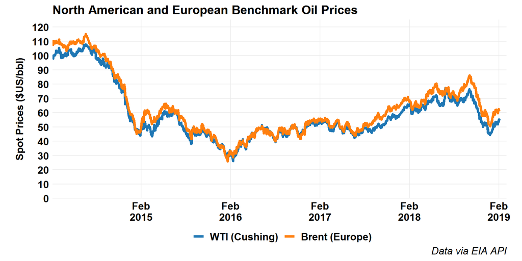

The EIA data library also provides a lot of other prices and we can use those to produce some of the other types of graphs we use in the class. For example, if you’re interested in refining margins, you can look at New York Harbour and Gulf Coast 3:2:1 crack spreads: the difference between the value of crude oil and the value of a refined product yield of 2/3 gasoline and 1/3 diesel.

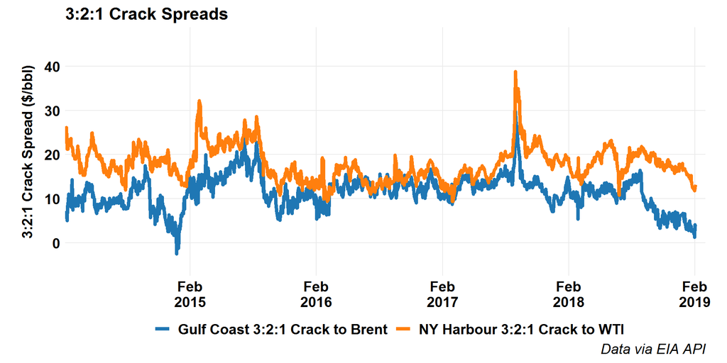

```r
# first, make the cracks
daily_crude<-daily_crude %>% mutate(
  gc_321=U.S..Gulf.Coast.Ultra.Low.Sulfur.No.2.Diesel.Spot.Price..Daily*42/3+ U.S..Gulf.Coast.Conventional.Gasoline.Regular.Spot.Price.FOB..Daily*42*2/3-Europe.Brent.Spot.Price.FOB..Daily,
  nyh_321=New.York.Harbor.Ultra.Low.Sulfur.No.2.Diesel.Spot.Price..Daily*42/3+New.York.Harbor.Conventional.Gasoline.Regular.Spot.Price.FOB..Daily*42*2/3 -Cushing..OK.WTI.Spot.Price.FOB..Daily
)

names<-c("gc_321","nyh_321")
name_labels<-c("Gulf Coast 3:2:1 Crack to Brent","NY Harbour 3:2:1 Crack to WTI")
years<-5
break_set<-"12 months"
title<-"3:2:1 Crack Spreads"
y_label<-"3:2:1 Crack Spread ($/bbl)"

levels_chart(daily_crude,names,name_labels,years = years,title_sent = title,y_lab = y_label)
```

# Weekly Petroleum Status Report

The EIA Weekly Petroleum Status Report is one of the most-watched data releases in energy markets. The report is released at 10:30 a.m. (Eastern time) on Wednesdays every week, with publication of the data to the API after 1:00 p.m. (Eastern Time) on Wednesday. You can see the full Petroleum Status Report [here](https://www.eia.gov/petroleum/supply/weekly/) or you can access via the EIA API starting from [here](https://www.eia.gov/opendata/qb.php?category=235079). For most of what follows, I’ll be using three data series: the full US weekly supply [here](https://www.eia.gov/opendata/qb.php?category=235081) and the Cushing oil stocks data [here](https://www.eia.gov/opendata/qb.php?category=235418). You can download the data any way you like, but for this purpose, I’m grabbing the data with R as follows:

```r
#first, build a list of series names we want to access
#get the information from the EIA weekly supply API
cat_store <- list()
name_store<-list()

subs<-data_fetch(KEY,cat=235081)
#take out the 4 week average data
series_ids<-subs$Series_IDs$series_id[-grep("\\b.4\\b",subs$Series_IDs$series_id)]
#make sure series ids aren't stored as factors
series_ids<- as.character(series_ids)
#same for names
names<-t(subs$Series_IDs$name[-grep("\\b.4\\b",subs$Series_IDs$series_id)])
cat_store[[1]]<-series_ids
name_store[[1]]<-names


#get the Cushing series ids and names
subs<-data_fetch(KEY,cat=235418)
series_ids<-subs$Series_IDs$series_id[]
names<-t(subs$Series_IDs$name[])
cat_store[[2]]<-series_ids
name_store[[2]]<-names

#get the gas storage series and IDs
subs<-data_fetch(KEY,cat=1709237)
series_ids<-subs$Series_IDs$series_id[]
names<-t(subs$Series_IDs$name[])
cat_store[[3]]<-series_ids
name_store[[3]]<-names

#stack all of them
series<-data.frame(do.call(c,cat_store))
name_list<-do.call(c,name_store)

#fetchez le data
all_data<- pdfetch_EIA(t(series),KEY)
all_data<-data.frame(date=index(all_data), coredata(all_data))
#fix the data names list
name_list<- gsub("\\.", " ", name_list)
name_list<- gsub("\\U S ", "US", name_list)
name_list<- gsub("  ", " ", name_list)
name_list<- gsub(", Weekly", "", name_list)
name_list<- gsub("US ", "", name_list)
name_list<- gsub("U S ", "", name_list)
name_list<- gsub("^\\s+|\\s+$", "",name_list)
#assign names
all_data <- setNames(all_data,c("date",name_list))
#build week and year indicators
all_data<-all_data%>% mutate(
week=week(date),
month=month(date),
year=year(date)
)
```

The weekly petroleum supply information is very detailed, and you’ll see markets move in response to its release. The most important series traders will watch are production, inventories, and trade data. I set up a basic graph to allow me to quickly compare the current release data with previous years and the trailing 5 year range. The graph code is provided under the Code icon for your reference.

```r
ribbon_graph<-function(data_sent,series_name,unit_sent,years,alt_axis=FALSE){
#melt the data into long form
df1<-melt(data_sent,id=c("date","week","month","year"),measure.vars = series_name)
#remove NAs
df1<-na.omit(df1)
#truncate to 52 weeks for the years where there is a 53rd week.
df1$week[df1$week==53]<-52

#create range data
max_year<-max(df1$year)

#first, we want the ones we are going to graph - this year and last year
df.years <- df1 %>%
  filter(year >= max_year-1)

#now we want the ones for the range
df.year.range <- df1 %>%
  filter(year >= max_year - years & year < max_year) %>%
  group_by(week) %>%
  summarize(mean = mean(value), min = min(value), max = max(value))

y_lab<-paste(alt_axis,"\n(",unit_sent,")",sep="")
if(alt_axis==FALSE)
  y_lab<-paste(series_name,"\n(",unit_sent,")",sep="")

#We can then trick ggplot into printing a nice title for the fill on the legend, by setting fill inside aes to the intended string. Because fill is set in aes(), we control its color with scale_fill_manual.
graph<- ggplot() +
  geom_ribbon(data = df.year.range, aes(x = week, ymin = min, ymax = max, fill =  "fill1")) +
  geom_line(data = df.year.range, aes(x = week, y = mean,colour="3"),size=1.7) +
  geom_line(data = subset(df.years,year==max_year-1), aes(x = week, y = value, color = "2"),size=1.7)+
  geom_line(data = subset(df.years,year==max_year), aes(x = week, y = value, color = "1"),size=1.7) +
  geom_point(data = subset(df.years,year==max_year), aes(x = week, y = value, color = "1"),size=1.7) +
  #scale_fill_manual(values = '#ffccff')
  scale_fill_manual("",values = 'grey70',labels=paste(max_year-years,"-",max_year-1,"\nrange",sep =""))+
  scale_color_viridis("",discrete=TRUE,option="C",labels=c(max_year, max_year-1,paste(max_year-years,"-",max_year-1,"\naverage",sep ="")))+
  #scale_fill_continuous()+
  scale_x_continuous(limits=c(min(df1$week),max(df1$week)),expand=c(.001,0))+
  theme_minimal()+
  theme(
    legend.position = "bottom",
    legend.margin=margin(c(0,0,0,0),unit="cm"),
    legend.text = element_text(colour="black", size = 12),
    plot.caption = element_text(size = 14, face = "italic"),
    plot.title = element_text(face = "bold"),
    plot.subtitle = element_text(size = 14, face = "italic"),
    #panel.grid.minor = element_blank(),
    text = element_text(size = 14,face = "bold"),
    axis.line = element_line(color="black", size = 1),
    axis.text.y =element_text(size = 14,face = "bold", colour="black"),
    axis.text.x=element_text(size = 14,face = "bold", colour="black",angle=90, hjust=1),
  )+
  labs(y=y_lab,x="Week",
       title=paste(series_name,sep=""),
       caption="Source: EIA API, graph by Andrew Leach.")
print(graph)
}
```

## Crude Production

Certainly, the most-watched element in the data most weeks will be the US crude production data. The below shows the previous 5 year range of production as well as the previous 5 year average, current year, and previous year’s time series.

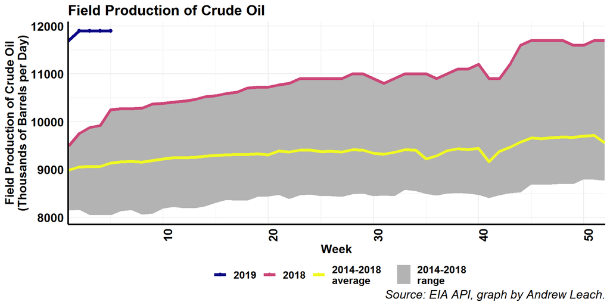

## Crude Trade

Over the past decade, the US has moved from a major crude oil importer to a major crude oil exporter. Net imports have also decreased. Below, I’ve included both the total imports and exports as well as net imports data, with 10 year ranges and averages, as well as the current year, and previous year’s time series.

### Crude Imports

Displays the most recent crude import data and historic ranges.

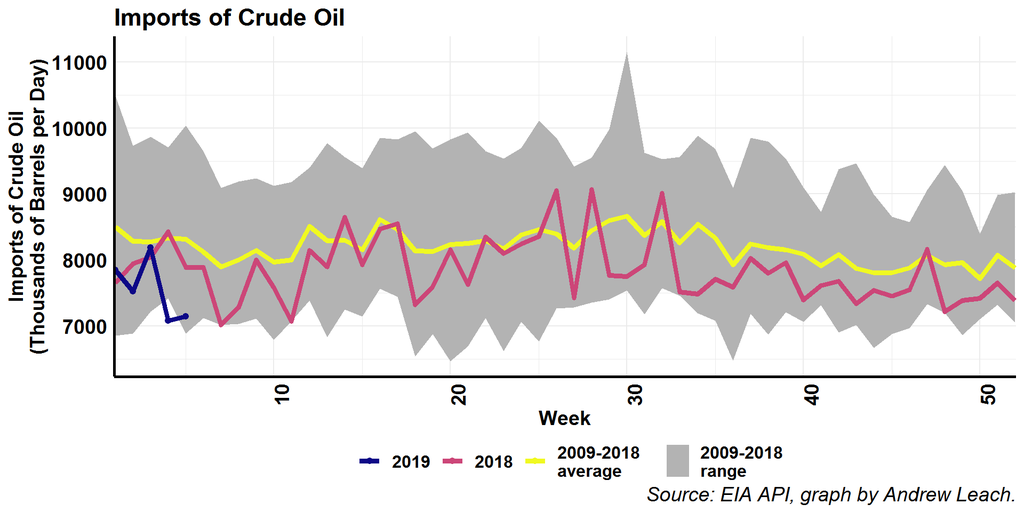

### Crude Exports

Displays the most recent crude export data and historic ranges.

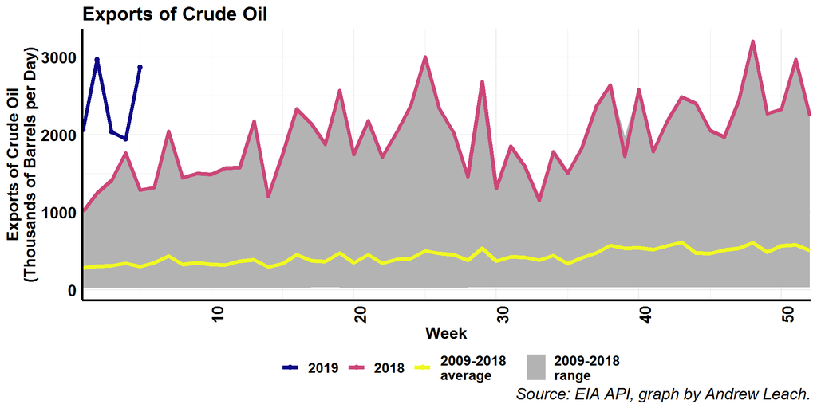

### Net Imports

Displays the most recent crude net imports data and historic ranges.

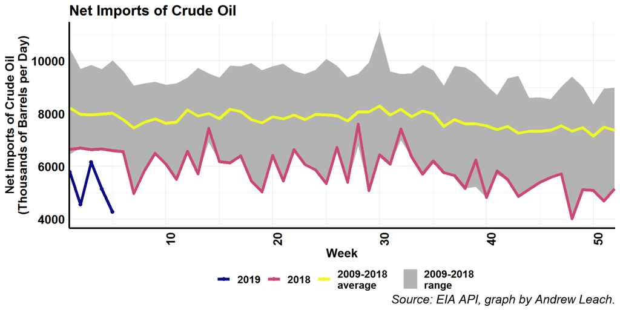

## Total Products Trade

Refined products like gasoline, diesel and jet fuel are traded just as crude oil is, and the US trade picture has also been changing a lot on the products front.

### Products Imports

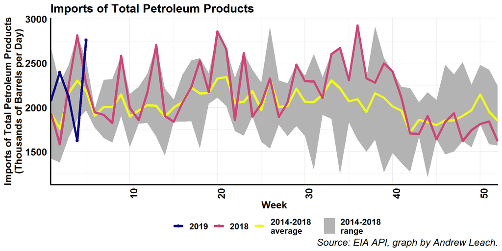

### Products Exports

[figure not shown]

### Net Imports of Crude Oil and Petroleum Products

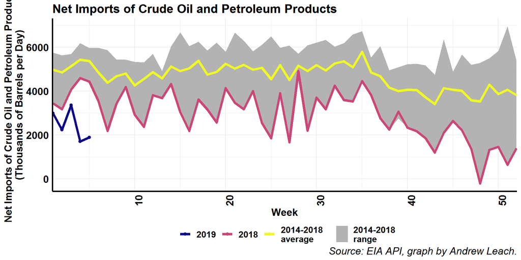

Below, I’ve also included some key graphs for gasoline and diesel.

## Gasoline and Diesel Trade

Each of the graphs shows the 5 year range of data as well as the 5 year average, current year, and previous year’s time series for the key refined products we’ll talk about in class.

### Gasoline Imports

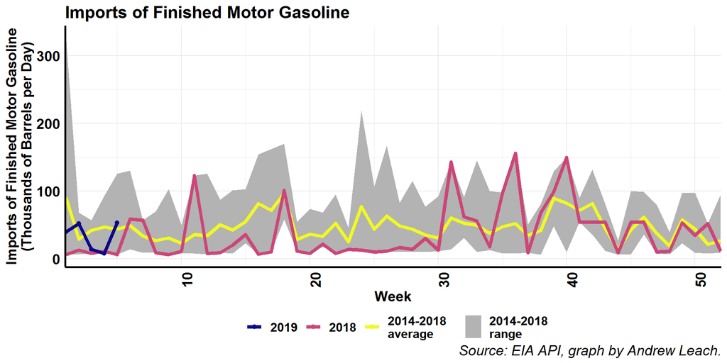

### Gasoline Exports

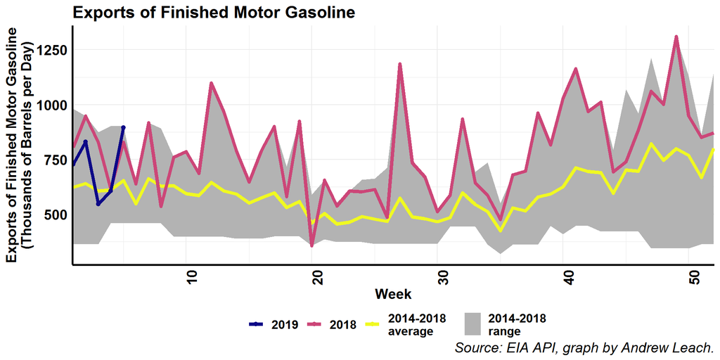

### Diesel Imports

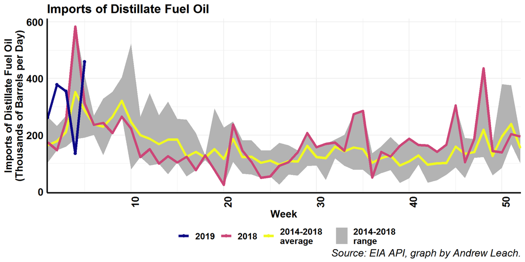

### Diesel Exports

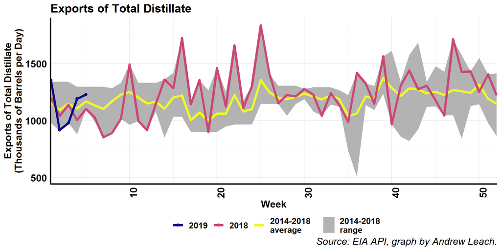

### Jet Imports

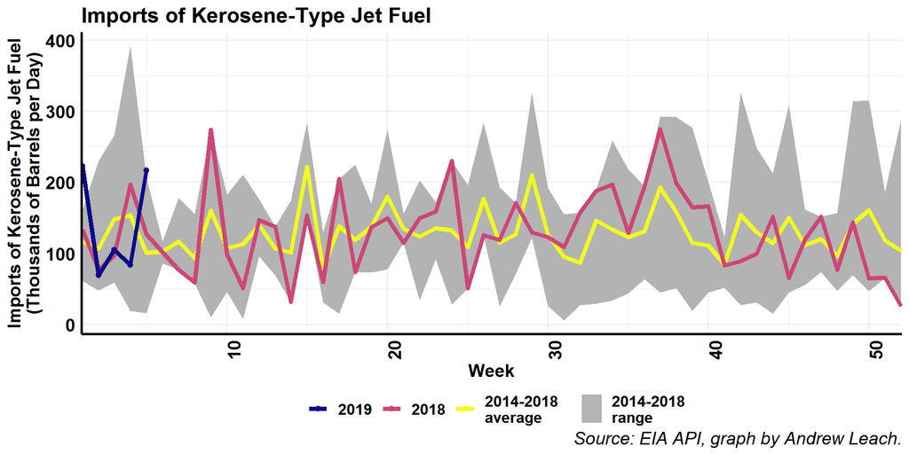

### Jet Exports

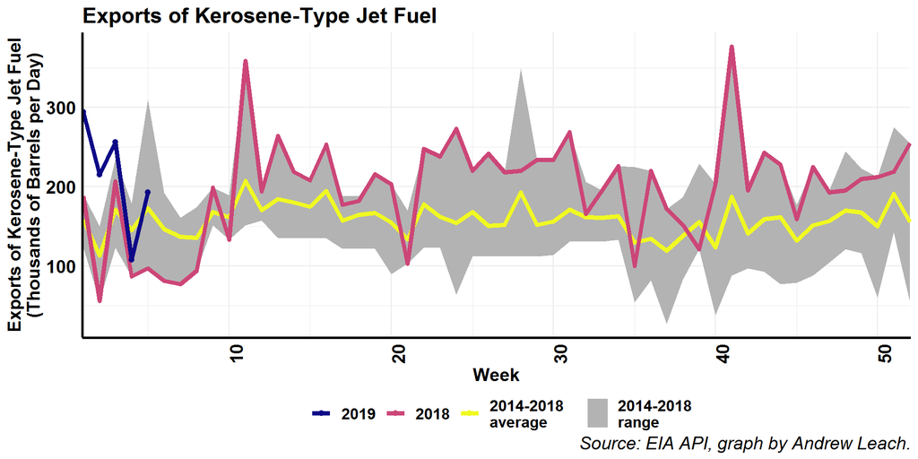

## Crude and Products Storage

The other markers that people will pay a lot of attention to in the Weekly Petroleum Status Report are storage levels for crude oil and refined products. Inventory changes tell us how quantities supplied and imported related to quantities consumed and exported, and also tell us whether the physical side of the market is looking bullish or bearish. As with the previous graphs, each of the graphs below shows the 5 year range of data as well as the 5 year average, current year, and previous year’s time series, but in this case the axis labels are in total storage levels.

### Crude

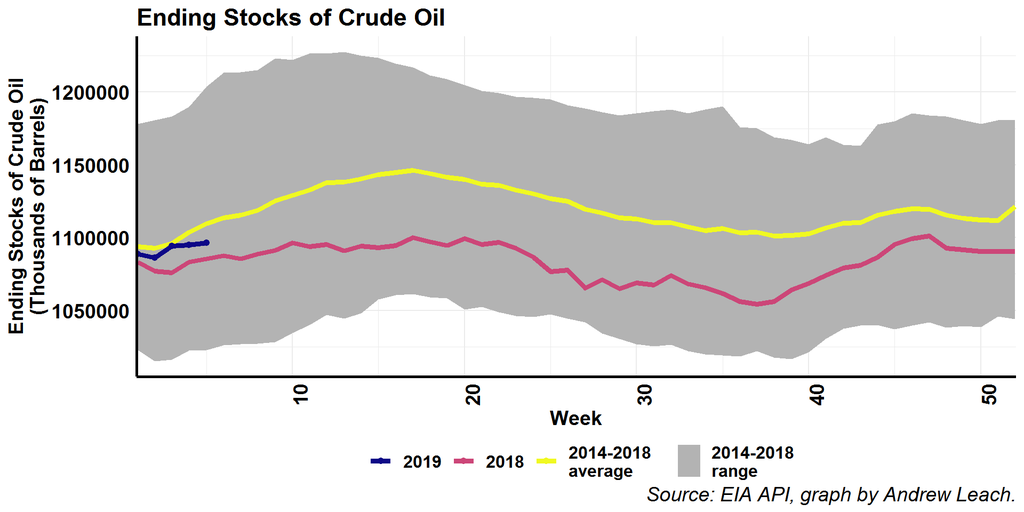

### Cushing Crude

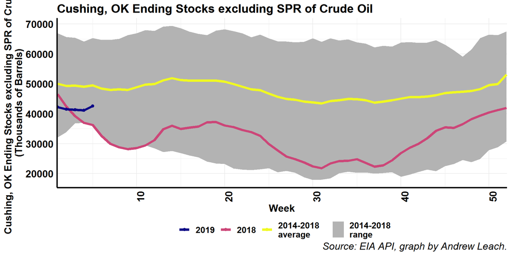

### Strategic Petroleum Reserve (SPR)

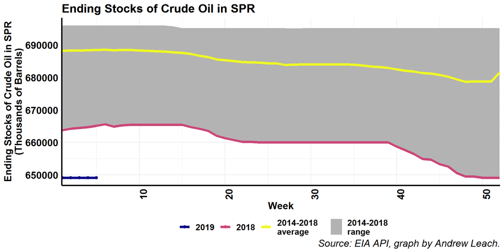

### Gasoline

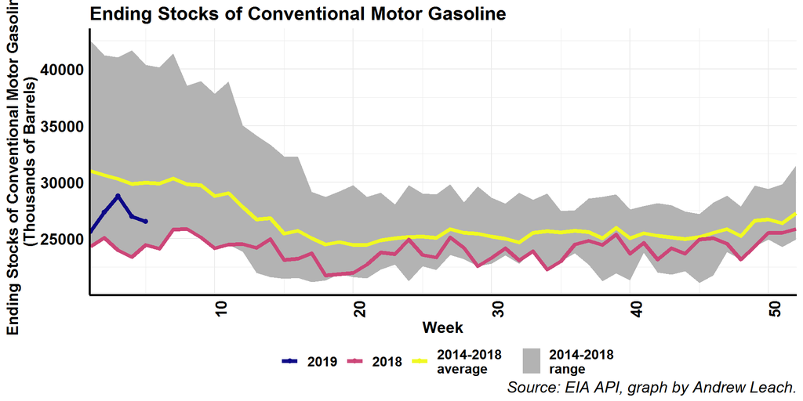

### Distillate

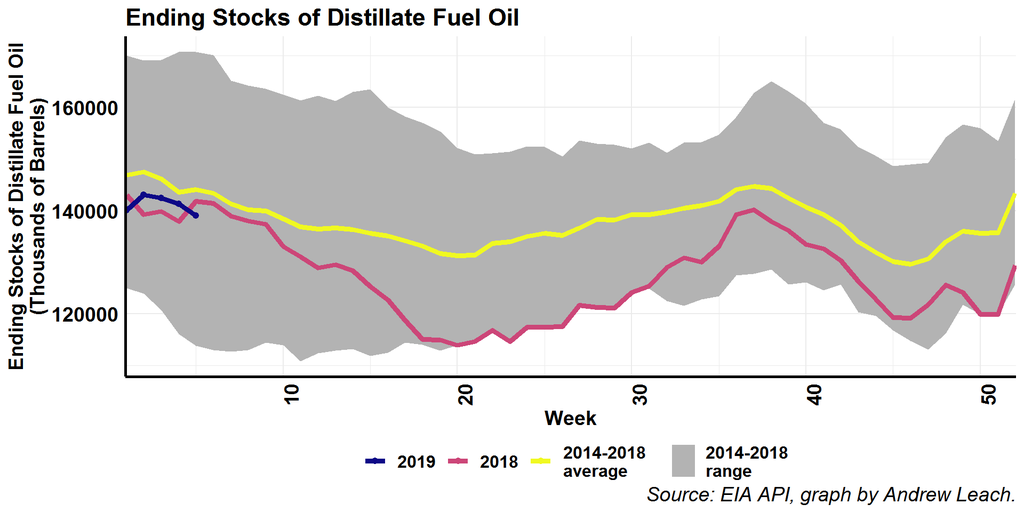

## Refining

The Weekly Petroleum Status Report also contains significant information on refining. A small sample of these are shown below. The Operable Distillation Capacity tells you what’s available each week in terms of conventional refining. We don’t have weekly operable capacity data on more complex units post-distillation, but the EIA does track these on a longer-term basis. We also have weekly data on inputs of crude oil to refineries as well as total production.

### Operable Distillation Capacity

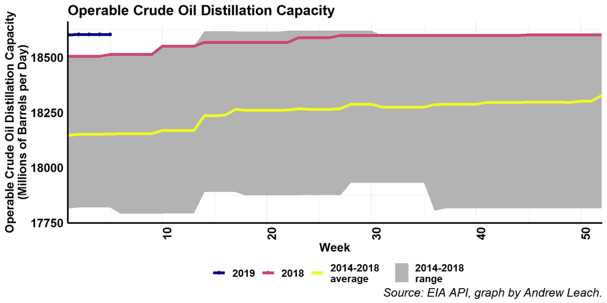

### Gross Inputs to Refineries

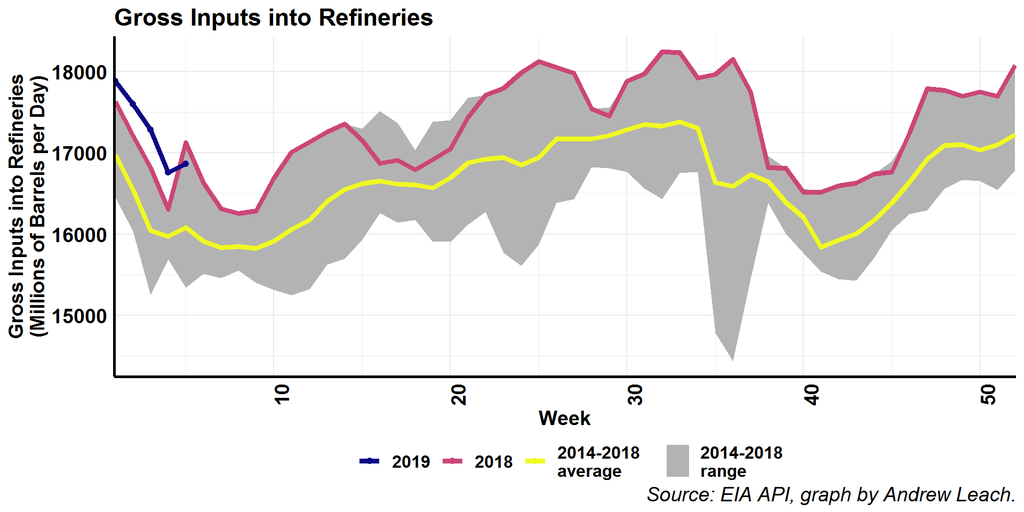

### Net Production of Gasoline

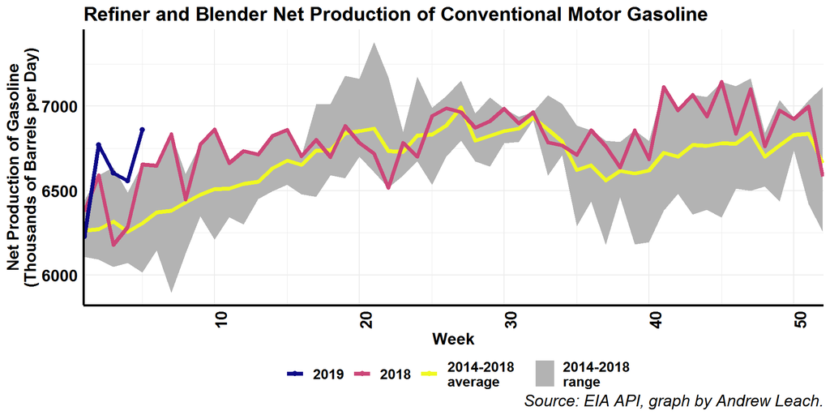

### Net Production of Diesel

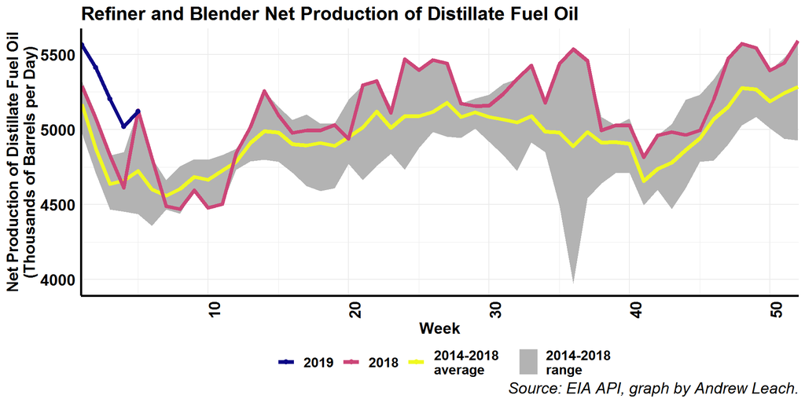

# Weekly Natural Gas Storage Report

The weekly gas storage report is available [here](http://ir.eia.gov/ngs/ngs.html) or via the API [here](https://www.eia.gov/opendata/qb.php?category=1709237). I’ve included it in my code above, so there’s no separate data pull for this section, and the graphs rely on the same code as above. Natural gas storage and use is much more seasonal than oil, so you can really see the inventory builds following a pattern that you don’t see in oil markets to the same degree. As above, each of the graphs I’ve provided below shows the 5 year range of data as well as the 5 year average, current year, and previous year’s time series.

## Lower 48 States Natural Gas Working Underground Storage

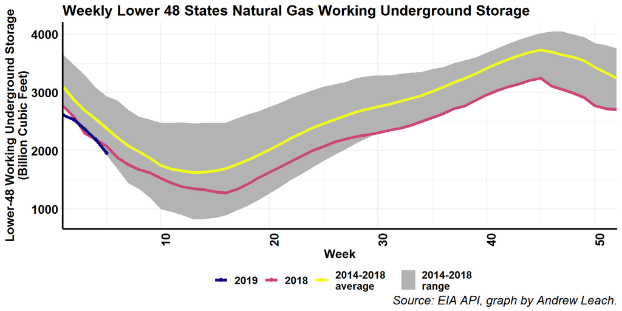

## East Region Natural Gas Working Underground Storage

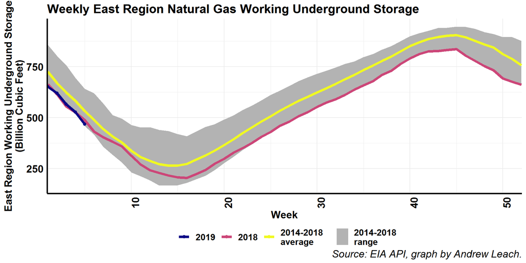

# Oil and gas production updates

## Monthly Production Updates by State and/or Area

The key longer-term data series that the EIA provides on oil and gas production are also found either on their website [here](https://www.eia.gov/petroleum/production/) for oil and gas. I’ll use the API [here](https://www.eia.gov/opendata/qb.php?category=296686) for oil production by state, [here](https://www.eia.gov/opendata/qb.php?category=2477496) for oil production by API gravity, and [here](https://www.eia.gov/opendata/qb.php?category=474572) for gas. As above, you can download the data any way you like, but for this purpose, I’m again grabbing and cleaning the data with R as follows:

```r
#first, build a list of series names we want to access
#get the information from the EIA weekly supply API
cat_store <- list()
name_store<-list()
unit_store<-list()

#monthly crude production by Area
subs<-data_fetch(KEY,cat=296686)
#take out the 4 week average data
series_ids<-subs$Series_IDs$series_id[grep("\\.M\\b",subs$Series_IDs$series_id)]
#make sure series ids aren't stored as factors
series_ids<- as.character(series_ids)
#same for names
names<-t(subs$Series_IDs$name[grep("\\.M\\b",subs$Series_IDs$series_id)])
units<-subs$Series_IDs$units[grep("\\.M\\b",subs$Series_IDs$series_id)]

cat_store[[1]]<-series_ids
name_store[[1]]<-names
unit_store[[1]]<-units


#get the natural gas production data
subs<-data_fetch(KEY,cat=474572)
series_ids<-subs$Series_IDs$series_id[grep("\\.M\\b",subs$Series_IDs$series_id)]
#make sure series ids aren't stored as factors
series_ids<- as.character(series_ids)
#same for names
names<-t(subs$Series_IDs$name[grep("\\.M\\b",subs$Series_IDs$series_id)])
units<-subs$Series_IDs$units[grep("\\.M\\b",subs$Series_IDs$series_id)]

cat_store[[2]]<-series_ids
name_store[[2]]<-names
unit_store[[2]]<-units
#get crude production by API gravity
subs<-data_fetch(KEY,cat=2477496)
series_ids<-subs$Series_IDs$series_id[grep("\\.M\\b",subs$Series_IDs$series_id)]
units<-subs$Series_IDs$units[grep("\\.M\\b",subs$Series_IDs$series_id)]

#make sure series ids aren't stored as factors
series_ids<- as.character(series_ids)
#same for names
names<-t(subs$Series_IDs$name[grep("\\.M\\b",subs$Series_IDs$series_id)])
cat_store[[3]]<-series_ids
name_store[[3]]<-names
unit_store[[3]]<-units
#stack all of them
series<-data.frame(do.call(c,cat_store))
name_list<-do.call(c,name_store)
units<-do.call(c,unit_store)
#fetchez le data
production_data<- pdfetch_EIA(t(series),KEY)
production_data<-data.frame(date=index(production_data), coredata(production_data))
#store units
attributes(production_data)$units<-c("Date",units)
#fix the data names list
name_list<- gsub("\\.", " ", name_list)
name_list<- gsub("\\U S ", "US", name_list)
name_list<- gsub("  ", " ", name_list)
name_list<- gsub(", Monthly", "", name_list)
name_list<- gsub("US ", "", name_list)
name_list<- gsub("U S ", "", name_list)
name_list<- gsub("^\\s+|\\s+$", "",name_list)
#assign names
production_data <- setNames(production_data,c("Date",name_list))

full_names<-paste(name_list,units,sep=", ")
production_data <- setNames(production_data,c("Date",full_names))

#build week and year indicators
production_data<-production_data%>% mutate(
week=week(Date),
month=month(Date),
year=year(Date)
)
```

These data are super-rich and far exceed the level of detail we’re going to need in the class. However, one thing we will talk a lot about is US regional crude production so let’s use this as an example for these data. First, as above, we need some graphing preliminaries

```r
#define production chart design function
#default will be oil
oil_production_chart<-function(data_sent,names,name_labels,years,title_sent="Benchmark Oil Prices",break_set="12 months",y_lab="Production (Thousands of Barrels Per Day)")
{
  #send a data set and variable names
  #testing
    #data_sent<-daily_crude
    #names<-"Europe.Brent.Spot.Price.FOB..Daily"
    #name_labels<-"Brent"
    #years<-5
    #break_set<-"12 months"
    #title_sent<-"Benchmark Oil Prices"
  rows_legend<-max(1,round(sum(nchar(names))/180))
  data_sent<-filter(data_sent,Date>=max(Date)-years(years))
  df1<-melt(data_sent,id=c("Date"),measure.vars = names)
  df1<-na.omit(df1)
  lims<-c(max(df1$Date)-years(years),max(df1$Date)+months(1))
  lims_y<-c(0,max(df1$value)*1.1)

  p<-ggplot(df1) +
    geom_line(data=filter(df1,variable!="diff"),aes(Date,value,group = variable,colour=variable),size=1.7) +
    #geom_point(size=1) +
    scale_colour_manual(NULL,values=colors_tableau10(), labels=name_labels)+
    scale_x_date(name=NULL,date_breaks = break_set, date_labels =  "%b\n%Y",limits=lims,expand=c(0,0)) +
    scale_y_continuous(expand = c(0,0),limits=lims_y) +
    guides(colour=guide_legend(nrow=rows_legend))+
    labs(y=y_lab,x="Date",
         title=title_sent,
         caption="Data via EIA API")+
    weekly_small()
  p
}
```

Now we can make the graphs we need. Start with a basic graph of US oil production.

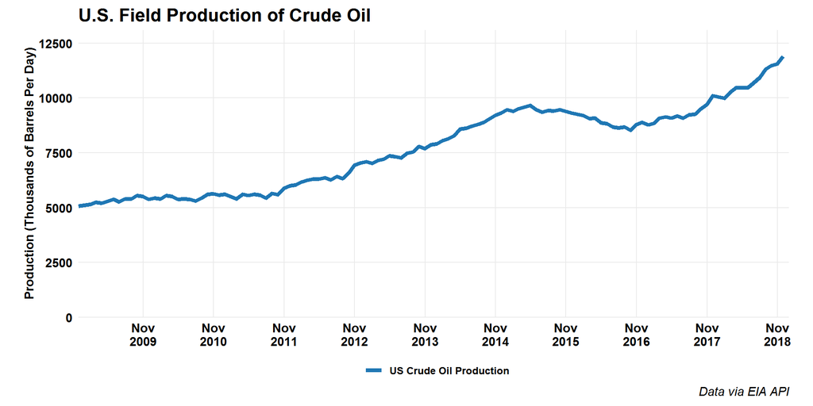

```r
names<-c("Field Production of Crude Oil, Thousand Barrels per Day")
name_labels<-c("US Crude Oil Production")
years<-10
break_set<-"12 months"
title_sent<-"U.S. Field Production of Crude Oil"
oil_production_chart(production_data,names,name_labels,years,title_sent=title_sent,break_set=break_set)
```

As mentioned above, regional production of crude oil is very important for Canada, as much of the growth in US production has occurred either in or closer to markets that we traditionally serve with our exports to the US.

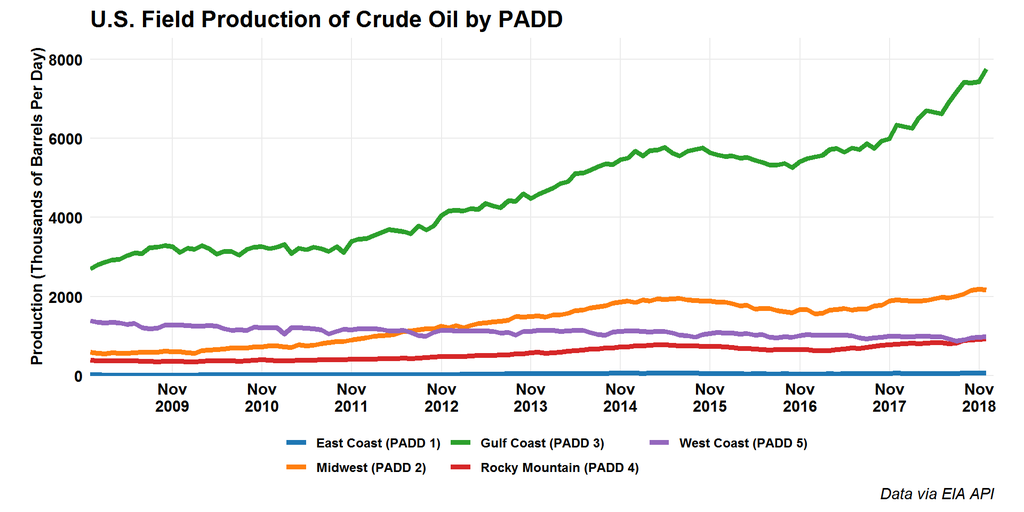

```r
names<-c("East Coast (PADD 1) Field Production of Crude Oil, Thousand Barrels per Day","Midwest (PADD 2) Field Production of Crude Oil, Thousand Barrels per Day","Gulf Coast (PADD 3) Field Production of Crude Oil, Thousand Barrels per Day","Rocky Mountain (PADD 4) Field Production of Crude Oil, Thousand Barrels per Day","West Coast (PADD 5) Field Production of Crude Oil, Thousand Barrels per Day")
name_labels<-c("East Coast (PADD 1)","Midwest (PADD 2)","Gulf Coast (PADD 3)","Rocky Mountain (PADD 4)","West Coast (PADD 5)")

years<-10
break_set<-"12 months"
title_sent<-"U.S. Field Production of Crude Oil by PADD"
oil_production_chart(production_data,names,name_labels,years,title_sent=title_sent,break_set=break_set)
```

There are many other sources of data in the reports, but this is enough of a sense of what’s possible for these purposes.

## Drilling Productivity Reports

The US EIA also produces the Drilling Productivity Report (DPR) which provides a select set of data by region for oil and shale gas production. The DPR is accessible on their website [here](https://www.eia.gov/petroleum/drilling/) or you can access the Excel spreadsheet directly [here](https://www.eia.gov/petroleum/drilling/xls/dpr-data.xlsx). Again, the code link shows the means of downloading and processing the data via R.

```r
dpr_file<-"https://www.eia.gov/petroleum/drilling/xls/dpr-data.xlsx"

download.file(dpr_file,"dpr-data.xlsx",mode="wb")
plays<-getSheetNames("dpr-data.xlsx")
plays<-plays[plays!="RegionCounties"]
wb <- loadWorkbook("dpr-data.xlsx")
cnames<-c("Month","Rigcount",   "Oil_Production_per_rig",   "Oil_Legacy_prod_chg",  "Total_oil_prod","Gas_Production_per_rig",  "Gas_Legacy_prod_chg",  "Total_gas_prod")


dpr_data<-data.frame()
for(play in plays){
  play_data <- read.xlsx(xlsxFile = "dpr-data.xlsx", sheet = play, startRow = 2,skipEmptyRows = TRUE,detectDates = TRUE)
  names(play_data)<-cnames
  play_data$play<-play
  dpr_data<-rbind(dpr_data,play_data)
}


dpr_data<-melt(dpr_data,id=c("Month","Total_oil_prod","Total_gas_prod"),measure.vars = c("play"),value.name = "Play")
dpr_data$variable<-NULL
dpr_data<-na.omit(dpr_data)
dpr_data$Play<-as.factor(dpr_data$Play)
```

There’s a ton of information in the DPR as well, but a quick snapshot here shows you production for shale gas and light tight oil by play based on the code included below.

```r
lto_dpr<-ggplot(dpr_data,aes(Month,Total_oil_prod/1000,group = Play,colour=Play,fill=Play)) +
  geom_area(position = "stack") +
  #geom_point(size=1) +
  scale_color_viridis("",discrete=TRUE,option="D")+
  scale_fill_viridis("",discrete=TRUE,option="D")+
  #scale_colour_brewer(NULL,labels=c("Gasoline Exports","Gasoline Imports","Net Gasoline Exports"),type = "seq", palette = "Paired", direction = 1)+
  #scale_x_date(date_breaks = "1 year", date_labels =  "%Y",limits=c(max(as.Date("2000-01-01"),min(df1$date)),Sys.Date()),expand=c(0,0)) +
  #scale_colour_manual(labels=c("Gasoline Exports","Gasoline Imports","Net Gasoline Exports",values=c("#41ae76","#238b45","#006d2c","#00441b","Black","Black","Black","Black"))+
  #scale_y_continuous(limits=c(min(df1$value),max(df1$value)),expand=c(0,0))+
  #scale_y_continuous(limits=c(min(df1$value),max(df1$value)),expand=c(0,0))+
  theme_minimal()+theme(
    legend.position = "bottom",
    legend.margin=margin(c(0,0,0,0),unit="cm"),
    legend.text = element_text(colour="black", size = 12),
    plot.caption = element_text(size = 14, face = "italic"),
    plot.title = element_text(face = "bold"),
    plot.subtitle = element_text(size = 14, face = "italic"),
    #panel.grid.minor = element_blank(),
    text = element_text(size = 14,face = "bold"),
    axis.text.y =element_text(size = 14,face = "bold", colour="black"),
    axis.text.x=element_text(size = 14,face = "bold", colour="black",angle=90, hjust=1),
  )+
  labs(y="Crude Oil Production by Play \n(Monthly, Thousands of Barrels per Day)",x="Week",
       title=paste("US Production of Tight Oil",sep=""),
       caption="Source: EIA DPR, graph by Andrew Leach.")

lto_no_permian<-ggplot(subset(dpr_data,Play != "Permian Region"),aes(Month,Total_oil_prod/1000,group = Play,colour=Play,fill=Play)) +
  geom_area(position = "stack") +
  #geom_point(size=1) +
  scale_color_viridis("",discrete=TRUE,option="D")+
  scale_fill_viridis("",discrete=TRUE,option="D")+
  #scale_colour_brewer(NULL,labels=c("Gasoline Exports","Gasoline Imports","Net Gasoline Exports"),type = "seq", palette = "Paired", direction = 1)+
  #scale_x_date(date_breaks = "1 year", date_labels =  "%Y",limits=c(max(as.Date("2000-01-01"),min(df1$date)),Sys.Date()),expand=c(0,0)) +
  #scale_colour_manual(labels=c("Gasoline Exports","Gasoline Imports","Net Gasoline Exports",values=c("#41ae76","#238b45","#006d2c","#00441b","Black","Black","Black","Black"))+
  #scale_y_continuous(limits=c(min(df1$value),max(df1$value)),expand=c(0,0))+
  #scale_y_continuous(limits=c(min(df1$value),max(df1$value)),expand=c(0,0))+
  theme_minimal()+theme(
    legend.position = "bottom",
    legend.margin=margin(c(0,0,0,0),unit="cm"),
    legend.text = element_text(colour="black", size = 12),
    plot.caption = element_text(size = 14, face = "italic"),
    plot.title = element_text(face = "bold"),
    plot.subtitle = element_text(size = 14, face = "italic"),
    #panel.grid.minor = element_blank(),
    text = element_text(size = 14,face = "bold"),
    axis.text.y =element_text(size = 14,face = "bold", colour="black"),
    axis.text.x=element_text(size = 14,face = "bold", colour="black",angle=90, hjust=1),
  )+
  labs(y="Crude Oil Production by Play \n(Monthly, Thousands of Barrels per Day)",x="Week",
       title=paste("US Production of Tight Oil ex Permian Basin",sep=""),
       caption="Source: EIA DPR, graph by Andrew Leach.")

gas_dpr<-ggplot(dpr_data,aes(Month,Total_gas_prod/10^6,group = Play,colour=Play,fill=Play)) +
  geom_area(position = "stack") +
  #geom_point(size=1) +
  scale_color_viridis("",discrete=TRUE,option="D")+
  scale_fill_viridis("",discrete=TRUE,option="D")+
  theme_minimal()+theme(
    legend.position = "bottom",
    legend.margin=margin(c(0,0,0,0),unit="cm"),
    legend.text = element_text(colour="black", size = 12),
    plot.caption = element_text(size = 14, face = "italic"),
    plot.title = element_text(face = "bold"),
    plot.subtitle = element_text(size = 14, face = "italic"),
    #panel.grid.minor = element_blank(),
    text = element_text(size = 14,face = "bold"),
    axis.text.y =element_text(size = 14,face = "bold", colour="black"),
    axis.text.x=element_text(size = 14,face = "bold", colour="black",angle=90, hjust=1),
  )+
  labs(y="Shale and Tight Gas Production by Play \n(Monthly, Billion Cubic Feet per Day)",x="Week",
       title=paste("US Production of Tight and Shale Gas",sep=""),
       caption="Source: EIA DPR, graph by Andrew Leach.")
```

### Gas Production by Play

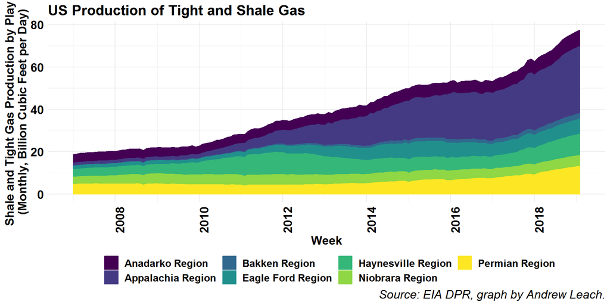

### Oil Production by Play

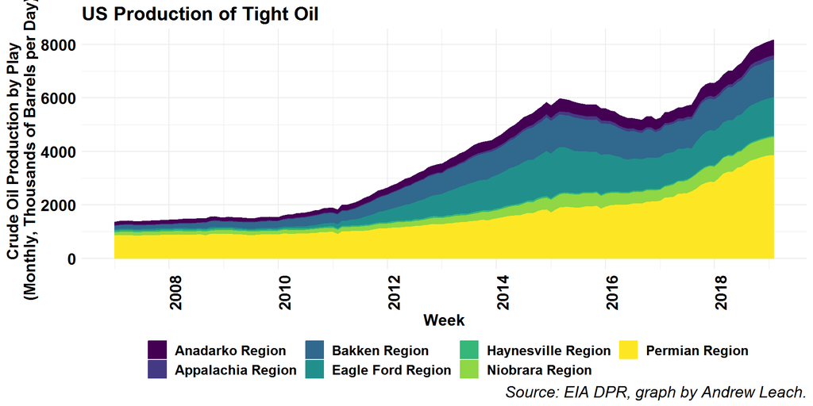

## Shale Gas and Light Tight Oil Production Reports

Finally for current data, the US EIA also produces a shale gas and light tight oil spreadsheet with data by play which is slightly different than the DPR data - it’s more disaggregated. You can access the Excel spreadsheet directly [here](https://www.eia.gov/energyexplained/data/U.S.%20tight%20oil%20production.xlsx) for oil and [here](https://www.eia.gov/energyexplained/data/U.S.%20dry%20shale%20gas%20production.xlsx%22) for gas. Again, the code link shows the means of downloading and processing the data via R.

```r
oil_prod_file<-"https://www.eia.gov/energyexplained/data/U.S.%20tight%20oil%20production.xlsx"

download.file(oil_prod_file,"play-data.xlsx",mode="wb")
#plays<-getSheetNames("play-data.xlsx")
#plays<-plays[plays!="RegionCounties"]
play_data <- read.xlsx(xlsxFile = "play-data.xlsx", sheet = "data", startRow = 1,skipEmptyRows = TRUE,detectDates = TRUE)
play_data$X17<-NULL
play_data$X12<-NULL
play_data$Date<-as.Date(play_data$Date,origin = "1899-12-30")
df1<-melt(play_data,id=c("Date"),variable.name = "play",value.name = "volume" )
df1$play<-gsub("\\.", " ", df1$play)
df1$play<-gsub("&N", " & N", df1$play)
df1$play<-gsub("  ", " ", df1$play)
df1$play<-gsub("  ", " ", df1$play)
df1$play<-gsub("Rest of US 'tight oil'","Other Tight Oil",df1$play)
df1$play<-factor(df1$play,levels = unique(df1$play))
df1$play<-fct_relevel(df1$play, "Other Tight Oil", after = Inf)

oil_play<-ggplot(df1,aes(Date,volume*1000,group = play,fill=play)) +
  geom_area(position = "stack") +
  scale_fill_viridis("",discrete=TRUE,option="D")+
  weekly_small()+guides(fill=guide_legend(nrow=3,byrow=TRUE))+
  labs(y="Tight Oil Production by Play \n(Monthly, Thousands of Barrels per Day)",x="Week",
       title=paste("US tight oil production estimates by play",sep=""),
       caption="Source: EIA data, graph by Andrew Leach.")
```

```r
gas_prod_file<-"https://www.eia.gov/energyexplained/data/U.S.%20dry%20shale%20gas%20production.xlsx"

download.file(gas_prod_file,"play-data.xlsx",mode="wb")
#plays<-getSheetNames("play-data.xlsx")
#plays<-plays[plays!="RegionCounties"]
play_data <- read.xlsx(xlsxFile = "play-data.xlsx", sheet = "data", startRow = 1,skipEmptyRows = TRUE,detectDates = TRUE)
play_data$X13<-NULL
play_data$Date<-as.Date(play_data$Date,origin = "1899-12-30")
df1<-melt(play_data,id=c("Date"),variable.name = "play",value.name = "volume" )
df1$play<-gsub("\\.", " ", df1$play)
df1$play<-gsub("&N", " & N", df1$play)
df1$play<-gsub("  ", " ", df1$play)
df1$play<-gsub("Rest of US 'shale'","Other Shale Plays",df1$play)
df1$play<-factor(df1$play,levels = unique(df1$play))
df1$play<-fct_relevel(df1$play, "Other Shale Plays", after = Inf)


gas_play<-ggplot(df1,aes(Date,volume,group = play,fill=play)) +
  geom_area(position = "stack") +
 geom_area(position = "stack") +
  scale_fill_viridis("",discrete=TRUE,option="D")+
  weekly_small()+guides(fill=guide_legend(nrow=3,byrow=TRUE))+
  labs(y="Shale Gas Production (Dry)\n(Monthly, Billion Cubic Feet per Day)",x="Week",
       title=paste("US shale gas production estimates by play",sep=""),
       caption="Source: EIA data, graph by Andrew Leach.")
```

Using the same basic graph code as for the DPR, we can see the results are comparable but with a little more disaggregation.

### Gas Production by Play

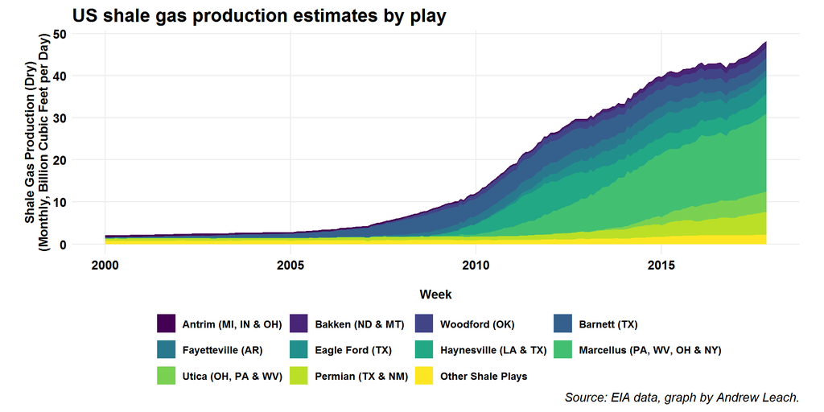

### Light Tight Oil Production by Play

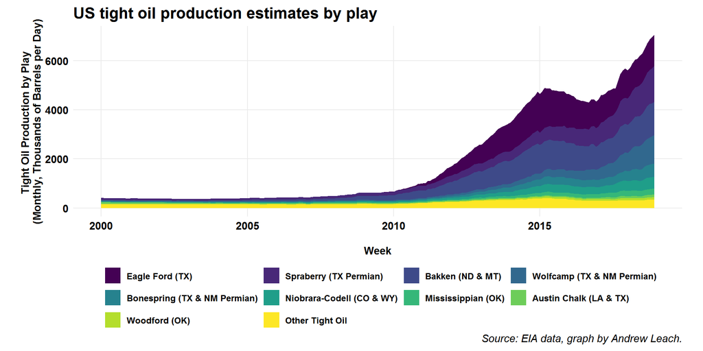

# US Trade with Canada

## Oil, Oil Products, and Natural Gas Liquids Trade

```r
#this section grabs data for trade with Canada

cat_store <- list()
name_store<-list()
unit_store<-list()
#Imports from Canada
subs<-data_fetch(KEY,cat=340981)
series_ids<-subs$Series_IDs$series_id[grep("\\.M\\b",subs$Series_IDs$series_id)]#monthly data
#same for names
names<-t(subs$Series_IDs$name[grep("\\.M\\b",subs$Series_IDs$series_id)])
#and units
units<-subs$Series_IDs$units[grep("\\.M\\b",subs$Series_IDs$series_id)]
cat_store[[1]]<-series_ids
name_store[[1]]<-names
unit_store[[1]]<-units

#Exports to Canada
subs<-data_fetch(KEY,cat=316977)
series_ids<-subs$Series_IDs$series_id[grep("\\.M\\b",subs$Series_IDs$series_id)]
#same for names
names<-t(subs$Series_IDs$name[grep("\\.M\\b",subs$Series_IDs$series_id)])
#and units
units<-subs$Series_IDs$units[grep("\\.M\\b",subs$Series_IDs$series_id)]
cat_store[[2]]<-series_ids
name_store[[2]]<-names
unit_store[[2]]<-units


#net imports will be in 323934

#Net Imports to Canada
subs<-data_fetch(KEY,cat=323934)
series_ids<-subs$Series_IDs$series_id[grep("\\.M\\b",subs$Series_IDs$series_id)]
#same for names
names<-t(subs$Series_IDs$name[grep("\\.M\\b",subs$Series_IDs$series_id)])
#and units
units<-subs$Series_IDs$units[grep("\\.M\\b",subs$Series_IDs$series_id)]
cat_store[[3]]<-series_ids
name_store[[3]]<-names
unit_store[[3]]<-units



#stack all of them
series<-data.frame(do.call(c,cat_store))
name_list<-do.call(c,name_store)
units<-do.call(c,unit_store)

#fetchez le data
cda_trade_data<- pdfetch_EIA(t(series),KEY)
cda_trade_data<-data.frame(date=index(cda_trade_data), coredata(cda_trade_data))
#store units
attributes(cda_trade_data)$units<-c("Date",units)
#fix the data names list
name_list<- gsub("\\.", " ", name_list)
name_list<- gsub("  ", " ", name_list) #take out extrac spaces
name_list<- gsub(", Monthly", "", name_list) #take out monthly label
name_list<- gsub("U.S. ", "", name_list)
name_list<- gsub("U S ", "", name_list)
name_list<- gsub("^\\s+|\\s+$", "",name_list)

#assign names
cda_trade_data <- setNames(cda_trade_data,c("Date",name_list))

full_names<-paste(name_list,units,sep=", ")
cda_trade_data <- setNames(cda_trade_data,c("Date",full_names))

#build week and year indicators
cda_trade_data<-cda_trade_data%>% mutate(
week=week(Date),
month=month(Date),
year=year(Date)
)

#We're interested in a few commodities

commod_list<-c("Conventional Motor Gasoline",
               "Crude Oil and Petroleum Products",
               "Residual Fuel Oil",
               "Propane",
               "Normal Butane",
               "Isobutane",
               "Pentanes Plus",
               "Natural Gas Liquids",
               #"Natural.Gasoline..Monthly",
               "Kerosene Type Jet Fuel",
               "Distillate Fuel Oil",
               "Distillate Fuel Oil, 0 to 15 ppm Sulfur",
               "Total Petroleum Products",
               "Crude Oil"
               )
commod_list<-paste(commod_list,"Thousand Barrels per Day",sep=", ")
#now cda_trade_data has what you need - call it to make the graphs
```

```r
  generic_trade_graph<-function(commod_sent,unit_sent="Thousand Barrels per Day"){
      #testing
      #commod_sent<-"Crude Oil and Petroleum Products"
      #unit_sent<-"Thousand Barrels per Day"
    export_field<-paste("Exports to Canada of ",commod_sent,", Thousand Barrels per Day",sep = "")
    net_import_field<-paste("Net Imports from Canada of ",commod_sent,", Thousand Barrels per Day",sep = "")
    import_field<-paste("Imports from Canada of ",commod_sent,", Thousand Barrels per Day",sep = "")

  #order is imports, exports, net imports
  df1<-melt(cda_trade_data,id=c("Date"),measure.vars = c(import_field,export_field,net_import_field))

  labels<-gsub(paste(",",unit_sent),"",levels(df1$variable))

  graph<-ggplot(df1,aes(Date,value,group = variable,colour=variable))+
    geom_line(size=1.7) +
    scale_color_manual("",values=colors_tableau10(),labels=labels)+
    scale_x_date(date_breaks = "1 year", date_labels ="%b\n%Y",limits=c(max(as.Date("2007-07-01"),min(df1$Date)),Sys.Date())) +
    #scale_colour_manual(labels=c("Gasoline Exports","Gasoline Imports","Net Gasoline Exports",values=c("#41ae76","#238b45","#006d2c","#00441b","Black","Black","Black","Black"))+
    #scale_y_continuous(limits=c(min(df1$value),max(df1$value)),expand=c(0,0))+
    #scale_y_continuous(limits=c(min(df1$value),max(df1$value)),expand=c(0,0))+
    guides(colour=guide_legend(nrow=2,byrow=TRUE))+
   weekly_small()+
    labs(y=paste("Monthly Trade (",unit_sent,")",sep=""),x="Year",
         title=paste("US ",commod_sent," Trade with Canada",sep=""),
         caption="Source: EIA API, graph by Andrew Leach.")
  graph
}
```